# Introdução à Ciência de Dados

Introdução à Inferência Estatística

Prof. Washington Santos da Silva

IFMG - Campus Formiga

27 de junho de 2025

## Diário de Bordo

**O que vimos até hoje?**

- Aula 1 ✅
  - Introdução e Contextualização ✅
  - O que é Ciência de Dados? ✅
  - Papéis Profissionais na Área de Dados ✅
  - Áreas de Aplicações ✅
  - Habilidades Interpessoais e Analíticas ✅
  - Apresentação da Disciplina ✅
- Aula 2 ✅
  - Metodologia CRISP-DM ✅
  - Tipos de Análise ✅
    - Descritiva ✅
    - Diagnóstica ✅
    - Preditiva ✅
    - Prescritiva ✅
  - Configurações: Git/GitHub ✅
- Aula 3 ✅
  - Introdução ao RStudio ✅
    - Criação do **seu** Projeto RStudio da Disciplina ✅
- Aula 4 ✅
  - Introdução ao Git e GitHub ✅
    - Criação do **seu** repositório do projeto RStudio da disciplina no GitHub ✅
- Aula 5 ✅
  - Breve Revisão do IDE RStudio ✅
  - Introdução ao Sistema de Publicação Quarto ✅
  - Sessão Prática Guiada com Relatório 1 ✅
    - Execução dos comandos git essenciais ✅
- Aula 6 ✅
  - Parte I ✅
    - O Relatório Junglivet e a Metodologia CRISP-DM ✅
    - Primeiro contato com a linguagem R por meio dos códigos do relatório ✅
  - Parte II ✅
    - Para alunos com projetos estruturados ✅
    - Atividade prática ✅
    - Para alunos com dificuldades técnicas ✅
    - Atendimento individualizado para estruturação de projetos ✅
- Aula 7 ✅
  - Introdução ao sistema Quarto (continuação) ✅
    - Gerar relatório no formato pdf ✅
    - Gerar relatório no formato docx ✅
  - Introdução à Linguagem R (continuação) ✅
    - Conceitos: Variáveis e observações ✅
    - Estrutura tabular organizada de dados ✅
    - Tipos e classes de dados principais em R ✅
    - Estruturas de dados: vetores e data frames ✅
- Aula 8 ✅
  - Início do estudo do pacote dplyr para manipulação de dados ✅
    - CRISP-DM: Fase 2 (Entendimento dos dados) e Fase 3 (Preparação dos dados) ✅  
      de um projeto de análise ou ciência de dados ✅
    - O que é o dplyr? ✅
    - A Filosofia *Tidy Data* (Dados Organizados) ✅
    - Dados Organizados (*Tidy Data*) ✅
    - Por que usar o dplyr? ✅
    - Fluxo de trabalho com dplyr ✅
    - Boas Práticas com dplyr ✅
    - Função dplyr::select() ✅
    - Função dplyr::filter() ✅
- Aula 9 ✅
  - Solução dos exercícios práticos sobre as funções select e filter ✅
  - Função dplyr::mutate() ✅
- Aula 10 ✅
  - Soluções dos exercícios práticos sobre a função mutate ✅
  - funções dplyr::group_by(), dplyr::summarize() e dplyr::arrange() ✅
- Aula 11 ✅
  - Metodologia CRISP-DM e Pacote dplyr ✅
  - Revisão sobre Dados Organizados (*Tidy Data*) ✅
  - Exemplos de Dados Desorganizados Comuns em Administração ✅
  - Pacote tidyr: Função pivot_longer ✅
- Aula 12 ✅
  - Metodologia CRISP-DM e o tidyverse ✅
  - Dados Organizados: Potencializando Análises ✅
- Aula 13 ✅
  - Avaliação 1 ✅
- Aula 14 ✅
  - Tipos Básicos de *joins* do pacote dplyr ✅
- Aula 15 ✅
  - Variáveis Aleatórias em Finanças ✅
  - Distribuições de Probabilidade ✅
  - Início: Distribuição Normal (ou Gaussiana) ✅
- Aula 16 ✅
  - Distribuição Normal (ou Gaussiana) - Parte 2 ✅
  - Características da Distribuição de uma VA ✅
    - Valor Esperado (Média) ✅
- Aula 17 ✅
  - Características da Distribuição de uma VA ✅
    - Variância e Desvio-Padrão ✅
    - Variância: Propriedades Básicas ✅
    - Aplicação: Valor-em-Risco (VaR) ✅
    - Assimetria e Curtose ✅
- Aula 18 ✅
  - Características da Distribuição de uma VA ✅
    - Covariância e Correlação ✅
    - Fundamentos de Simulação de Monte Carlo ✅
- Aula 19 ✅
  - Teoria da Probabilidade e Análise Estatística de Dados ✅
  - CRISP-DM e Análise Exploratória de Dados ✅
  - Análise Exploratória Numérica ✅
    - Medidas de Posição (ou de Tendência Central) ✅
    - Medidas de Variabilidade ✅
    - Medidas de Correlação ✅
- Aula 20 ✅
  - Análise Exploratória Gráfica ✅
    - Visualização de Dados e o Pacote ggplot2 ✅
    - Gráficos para Visualizar a Distribuição de Variáveis Numéricas ✅
      - Histograma ✅
      - Densidade Empírica (ou Kernel da Densidade) ✅
      - Boxplot ✅
      - Boxplot Comparativo ✅
- Aula 21 ✅
  - Gráfico Univariado para Variáveis Categóricas:
    - Gráfico de Barras (Barplot)
  - Gráficos Bivariados:
    - Gráficos de Barras Agrupadas e Empilhadas - Variáveis Categóricas
    - Gráfico de Dispersão - Variáveis Numéricas
  - Gráfico para Séries Temporais:
    - Gráfico de Linha Univariado (1 Série Temporal)
    - Gráfico de Linha Bivariado (2 Séries Temporais)
- Aula 22 ✅
  - Lista de Exercícios - Treino para Avaliação 2
- Aula 23 ✅
  - Avaliação 2
- Aula 24 ✅
  - CRISP-DM: Fase 4 - Modelagem/Análise
  - Introdução à Inferência Estatística
    - População e Amostra
    - Amostragem: Conceitos Básicos
    - Parâmetro, Estimador, Estimativa e Estatística

## Nesta Aula

**Tópicos**

- Introdução à Inferência Estatística
  - Distribuição Amostral da Média e Proporção
- Tópico Extra
  - Interpretação de Gráficos de Séries Temporais

**Diretrizes para Aulas Mais Produtivas**

🔊 **Mantenha conversas em volume baixo**

⌨️ **Código com método:**

95% dos erros são evitáveis com:

- Atenção na digitação
- Respeitar a sequência lógica de etapas
- Revisão antes de pedir ajuda

🤝 **Inteligência colaborativa:**

- Compartilhe conhecimento
- Resolva questões técnicas simples com colegas próximos
- Reserve ao professor as dúvidas conceituais complexas

💪 **Capacidade de Resolver Problemas**

Cada erro resolvido é uma evolução da sua habilidade analítica

# Distribuição Amostral

## O Problema Central da Inferência Estatística

**O que é uma Distribuição Amostral?**

Um analista de dados coleta uma amostra de 100 funcionários e calcula satisfação média $\bar{x} = 7.2$. Mas se ele repetisse o processo com outra amostra de 100 funcionários, obteria $\bar{x} = 7.0$. Uma terceira amostra resultaria em $\bar{x} = 7.4$.

**A Distribuição Amostral** é a distribuição de probabilidade de todas as possíveis médias amostrais que poderíamos obter se repetíssemos o processo de amostragem infinitas vezes.

**Por que isso é importante?** A distribuição amostral nos permite quantificar a variabilidade dos estimadores e fundamenta todos os métodos de inferência estatística.

## Distribuição Amostral da Média

**Demonstração Intuitiva**

- População com média $\mu$ e variância $\sigma^2$
- Amostra aleatória de tamanho $n$: $X_1, X_2, \dots, X_n$ (i.i.d.)
- Média amostral:

$$\bar{X} = \frac{1}{n} \sum_{i=1}^n X_i$$

- Valor Esperado da média amostral:

$$\mathbb{E}[\bar{X}] = \mathbb{E}\left[\frac{1}{n} \sum_{i=1}^n X_i\right] = \frac{1}{n} \sum_{i=1}^n \mathbb{E}[X_i] = \frac{1}{n} \cdot n \cdot \mu = \mu$$

- Variância da média amostral:

$$\text{Var}(\bar{X}) = \text{Var}\left( \frac{1}{n} \sum_{i=1}^n X_i \right) = \frac{1}{n^2} \sum_{i=1}^n \text{Var}(X_i) = \frac{1}{n^2} \cdot n \cdot \sigma^2 = \frac{\sigma^2}{n}$$

- Desvio-padrão da média amostral (Erro Padrão):

$$\text{EP}(\bar{X}) = \sqrt{\text{Var}(\bar{X})} = \sqrt{\frac{\sigma^2}{n}} = \frac{\sigma}{\sqrt{n}}$$

📦 **Interpretação**: Quanto maior a amostra, menor a variabilidade de $\bar{X}$. A média amostral é um estimador não-viesado de $\mu$.

## Forma da Distribuição de $\bar{X}$

**Dois Casos**

Caso 1: $X_i \sim N(\mu, \sigma)$

$$\bar{X} \sim N\left(\mu, \frac{\sigma}{\sqrt{n}}\right) \quad \text{quando } n \to \infty$$

Caso 2: $X_i$ não necessariamente normal

Pelo **Teorema Central do Limite (TCL)**:

$$\bar{X} \xrightarrow{d} N\left(\mu, \frac{\sigma}{\sqrt{n}} \right) \quad \text{quando } n \to \infty$$

**Nota**: O TCL exige que $\sigma^2 < \infty$ e que $X_i$ sejam i.i.d.

## Simulação da Distr. Amostral da Média

**Objetivo da Simulação**

- Simularemos 1.000 amostras diferentes para observar como as médias amostrais se distribuem.
- Isso permitirá visualizar concretamente o conceito de **distribuição amostral**, mesmo quando a população original **não é simétrica**.
- **Cenário**: População de 50.000 funcionários com níveis de satisfação gerados por uma **distribuição exponencial truncada** — ou seja, muitos com satisfação baixa, poucos com satisfação muito alta (assimetria à direita). Cada amostra terá 50 funcionários.
- **Meta**: Verificar se a distribuição amostral da média amostral se comporta como prevê o **Teorema Central do Limite**.

## Simulação da Distr. Amostral da Média

```
# A tibble: 3 × 2
  Parâmetro                  Valor
  <chr>                      <dbl>
1 μ (média populacional)      3.67
2 σ (desvio populacional)     3.04
3 N (tamanho)             50000
```

```
# A tibble: 5 × 2
  Propriedade                       Valor
  <chr>                             <dbl>
1 Média das médias amostrais        3.66
2 Erro padrão empírico (observado)  0.414
3 Erro padrão teórico (fórmula)     0.431
4 Média populacional (μ)            3.67
5 Diferença (empírico - teórico)   -0.017
```

## Distr. da População x Distr. Amostral da Média

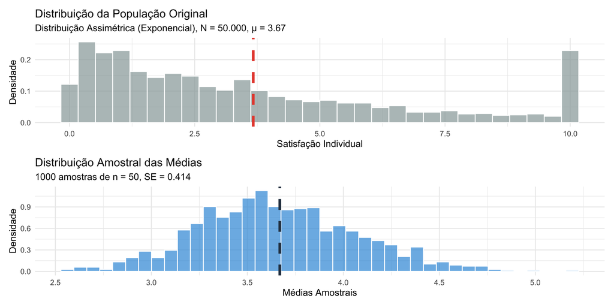

## Interpretação dos Resultados

**O Teorema Central do Limite em Ação**

Mesmo com uma população **fortemente assimétrica** (Exponencial), a distribuição das **médias amostrais** se aproxima de uma **normal**.

- Isso confirma: não precisamos de população normal para aplicar inferência baseada em média, apenas de um tamanho amostral razoável ($n \gtrapprox 30$).
- **Ponto-chave**: A distribuição amostral da média é **mais estável e simétrica** do que a própria população. Isso torna a média um ótimo estimador!

## Distribuição Amostral da Proporção

**Demonstração Intuitiva**

- População com proporção de sucesso $p$
- Amostra aleatória de tamanho $n$: variáveis indicadoras $X_1, X_2, \dots, X_n \in {0, 1}$, onde:

$$X_i =
\begin{cases}
1 & \text{se sucesso} \\
0 & \text{caso contrário}
\end{cases}$$

com $E[X_i] = p$ e $V(X_i) = p(1 - p)$

- Proporção amostral:

$$\hat{p} = \frac{1}{n} \sum_{i=1}^n X_i$$

- Valor Esperado da proporção amostral:

$$E[\hat{p}]
= E\left[\frac{1}{n} \sum_{i=1}^n X_i\right]
= \frac{1}{n} \sum_{i=1}^n E[X_i]
= \frac{1}{n} \cdot n \cdot p = p$$

- Variância da proporção amostral:

$$V(\hat{p})
= V\left(\frac{1}{n} \sum_{i=1}^n X_i\right)
= \frac{1}{n^2} \sum_{i=1}^n \text{Var}(X_i)
= \frac{1}{n^2} \cdot n \cdot p(1 - p)
= \frac{p(1 - p)}{n}$$

- Usa-se $V(aX) = a^2 V(X)$ e independência entre os $X_i$: $V\left(\sum X_i\right) = \sum V(X_i)$
- Erro padrão da proporção amostral:

$$\text{EP}(\hat{p}) = \sqrt{\frac{p(1 - p)}{n}}$$

- **Interpretação**: A proporção amostral $\hat{p}$ é um estimador não-viesado de $p$. Quanto maior $n$, menor a variabilidade.

## Forma da Distribuição de $\hat{p}$

**Dois Casos**

- **Caso 1: $n$ pequeno**

$\hat{p} = \dfrac{X}{n}$, onde $X \sim \text{Binomial}(n, p)$

→ A distribuição de $\hat{p}$ é **discreta**, pois $X$ é uma variável discreta.

→ Quando $p$ está próximo de 0 ou 1 e a amostra é pequena, a distribuição se comporta como um “dado viciado” — mais concentrada em 0 ou 1, e assimétrica.

- **Caso 2: $n$ grande**

Pelo **Teorema Central do Limite (TCL)**:

$$\hat{p} \approx N\left(p, \frac{p(1 - p)}{n} \right)$$

→ A distribuição de $\hat{p}$ pode ser aproximada por uma normal.

**Condições usuais para a aproximação normal serem válidas:**

$$np \ge 5 \quad \text{e} \quad n(1 - p) \ge 5$$

Essas condições garantem que a distribuição binomial esteja próxima da normal.

## Simulação: Proporção Amostral ($\hat{p}$) com População Pequena

**Simulação**

Agora, vamos simular **todas as amostras possíveis** de 5 elementos retirados **sem reposição** de uma população de apenas 20 indivíduos.

- 8 dos 20 estão satisfeitos ($p = 0.4$)
- Calculamos a proporção de satisfeitos em **todas as combinações** possíveis

Isso nos dá uma distribuição **exata** da proporção amostral $\hat{p}$.

## Simulação e Visualização: Distr. de $\hat{p}$ - Pop. Pequena

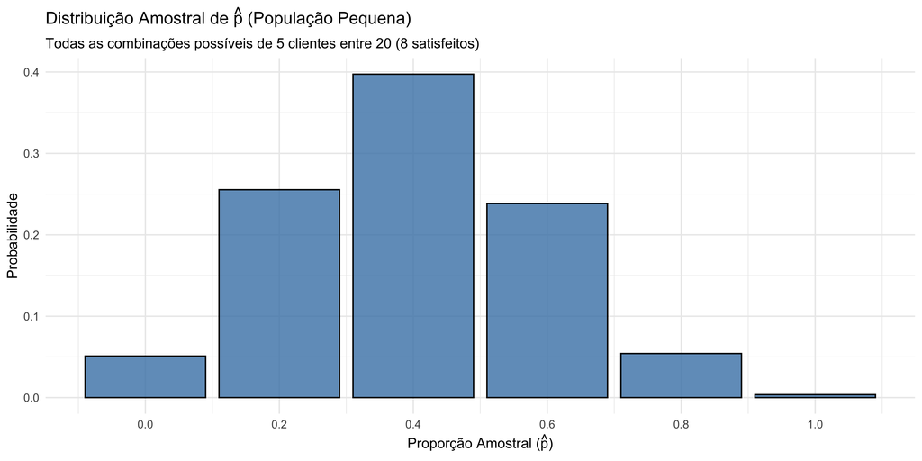

## Interpretação: População Pequena

**O que observamos?**

- A distribuição de $\hat{p}$ é **discreta**, com poucos valores possíveis.
- É **simétrica** em torno de $0.4$ (a proporção real da população).
- Como simulamos **todas as combinações possíveis**, essa é a distribuição **exata**, sem aproximações.
- A aproximação normal **não se aplica** nesse cenário com $n = 5$.

✅ Ideal para reforçar que, em populações pequenas ou com amostras p equenas, a inferência deve considerar a **distribuição binomial ou exata**, e não fórmulas normais.

## Simulação: Proporção Amostral ($\hat{p}$) - População Grande

**Simulação**

Vamos calcular a proporção amostral $\hat{p}$ para 800 amostras de tamanho 100, retiradas com reposição.

## Simulação e Visualização: Distr. de $\hat{p}$ - Pop. Grande

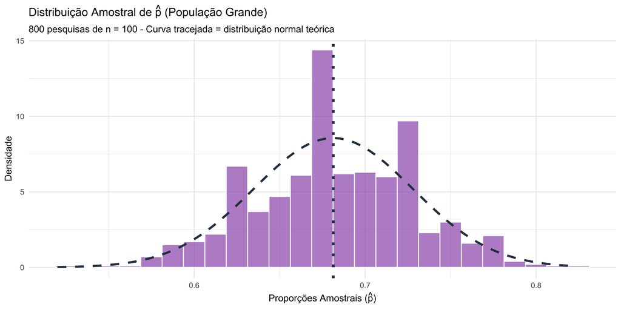

## Análise das Proporções Amostrais

```
# A tibble: 5 × 2
  Estatística                      Valor
  <chr>                            <dbl>
1 Proporção populacional (p)       0.681
2 Média das proporções amostrais   0.682
3 Erro padrão empírico (observado) 0.046
4 Erro padrão teórico (fórmula)    0.047
5 Diferença entre erros padrão     0
```

## Interpretação: População Grande

**O que observamos?**

## Teorema Central do Limite

**Demonstração com Distribuição Exponencial**

Usaremos uma distribuição exponencial (altamente assimétrica) para demonstrar que médias amostrais tendem à normalidade independentemente da forma populacional.

**Cenário**: Tempo entre chegadas de clientes (distribuição exponencial - muitas chegadas rápidas, poucas esperas longas).

## Distribuição Exponencial

**Resumo**

A distribuição exponencial modela o **tempo entre eventos aleatórios** que ocorrem a uma **taxa constante no tempo**.

É usada para descrever **tempos de espera entre eventos**, como:

- Tempo até a chegada de um cliente
- Tempo de resposta de um serviço
- Vida útil de um equipamento até falha

Seja $X \sim \text{Exponencial}(\lambda)$:

- $\lambda$ é a **taxa de ocorrência dos eventos por unidade de tempo**
- $X$ representa o tempo até o **próximo evento**

#### Propriedades

- **Função densidade de Probabilidade:**

$$f(x) = \lambda e^{-\lambda x}, \quad x \ge 0$$

- **Valor Esperado (Média):** $\mathbb{E}[X] = \frac{1}{\lambda}$
- **Variância:** $\text{Var}(X) = \frac{1}{\lambda^2}$
- **Desvio-padrão:** $\sigma = \frac{1}{\lambda}$
- A média e o desvio-padrão são **iguais** na exponencial — o que facilita a memorização!

#### Como simular com `rexp()` no R

Para gerar valores aleatórios com distribuição exponencial, usamos a função:

```r
rexp(n, rate = lambda)
```

🔎 Exemplo:

```r
rexp(9, rate = 0.25)
```

```
[1] 3.40906 0.21516 0.88472 9.13460 2.28940 1.43992 6.51687 6.01270 8.77200
```

**Interpretação**: Se $\lambda = 0.25$, estamos modelando eventos que ocorrem **a cada 4 unidades de tempo, em média**.

#### Forma da Distribuição

- Extremamente **assimétrica à direita**
- Valor mínimo: $0$
- **Cauda longa**: valores muito altos são raros, mas possíveis

## TCL: Visualizando a Convergência para Normalidade

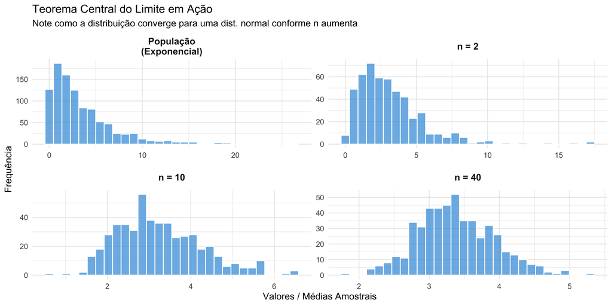

## Por que o TCL é um Pilar da Estatística?

**Importância do TCL**

- Permite usar **métodos baseados na distribuição normal** mesmo quando a população não segue uma dist. normal.
- É por isso que tantas fórmulas estatísticas envolvem a distribuição normal!
- Garante que estimativas médias têm distribuições previsíveis, mesmo em populações “estranhas”.

## Implicações do Teorema Central do Limite

**Consequências Práticas**

**Universalidade**: Independentemente da forma populacional, médias amostrais seguem distribuição normal para $n$ suficientemente grande. Isso funciona mesmo com distribuições muito assimétricas como a exponencial.

**Aplicabilidade**: Permite uso de métodos baseados na distribuição normal mesmo quando a população não é normal. Não precisamos conhecer a forma exata da população.

**Fundamento Teórico**: Explica por que a distribuição normal é central em estatística e análise de dados. É o resultado matemático que aparece naturalmente quando fazemos médias.

**Robustez**: Analistas podem aplicar técnicas de inferência sem conhecer a distribuição populacional completa. Isso torna os métodos estatísticos muito mais práticos e úteis.

## Síntese: Distribuições Amostrais

**Conceitos Fundamentais Consolidados**

**Definição**: Distribuição amostral é a distribuição de probabilidade de um estimador considerando todas as amostras possíveis de mesmo tamanho.

**Propriedades Essenciais**: Centro igual ao parâmetro populacional ($E[\bar{X}] = \mu$), dispersão que diminui com $\sqrt{n}$ ($SE = \frac{\sigma}{\sqrt{n}}$), e forma que tende à normal para amostras grandes.

**Teorema Central do Limite**: Garante normalidade das médias amostrais independentemente da forma da população original. É um dos resultados mais importantes da estatística.

**Aplicação Fundamental**: Serve como fundamento teórico para todos os métodos de inferência estatística que um analista de dados utiliza no dia a dia.

## Da Distribuição Amostral à Inferência Estatística

**Conectando Teoria e Aplicação**

As **distribuições amostrais** fornecem o fundamento teórico para todos os métodos de inferência que estudaremos a seguir.

**Intervalos de Confiança**: Usam as propriedades da distribuição amostral para estimar onde o parâmetro populacional provavelmente se encontra. O erro padrão calculado aqui determina a largura do intervalo.

**Testes de Hipóteses**: Comparam estimativas observadas com valores hipotéticos usando a distribuição amostral como referência. Se um resultado é “muito improvável” segundo a distribuição amostral, rejeitamos a hipótese.

**Bootstrap**: Simula empiricamente a distribuição amostral quando não conhecemos a teoria subjacente. É uma versão computacional do que fizemos aqui com simulações.

**Erro-padrão**: O erro-padrão derivado da distribuição amostral quantifica a incerteza dos estimadores. Quanto menor o erro padrão, mais precisa é a estimativa.

## Quiz: Distribuições Amostrais

**Verificação de Compreensão**

1. Para uma amostra de 36 observações com desvio-padrão s = 1.8, o erro-padrão de $\bar{x}$ é:
   1. 0.05
   2. 0.30
   3. 1.8
   4. 6.0
2. Para reduzir o erro-padrão de $\bar{x}$ pela metade, o tamanho da amostra deve ser:
   1. Dobrado
   2. Quadruplicado
   3. Reduzido pela metade
   4. Triplicado
3. O Teorema Central do Limite se refere à distribuição:
   1. Da população
   2. Da amostra
   3. Amostral do estimador
   4. Normal padrão

## Respostas

**Gabarito**

**1. Resposta: b) 0.30**

$SE = \frac{s}{\sqrt{n}} = \frac{1.8}{\sqrt{36}} = \frac{1.8}{6} = 0.30$

**2. Resposta: b) Quadruplicado**

O **erro-padrão da média amostral** $\bar{x}$ é dado por:

$$SE(\bar{x}) = \frac{\sigma}{\sqrt{n}}$$

Nosso objetivo é **reduzir o erro-padrão pela metade**. Suponha que o erro-padrão inicial seja:

$$SE_1 = \frac{\sigma}{\sqrt{n}}$$

Queremos que:

$$SE_2 = \frac{1}{2} \cdot SE_1 = \frac{1}{2} \cdot \frac{\sigma}{\sqrt{n}}$$

Vamos agora encontrar o novo tamanho da amostra, $n_2$, que torna isso possível:

$$SE_2 = \frac{\sigma}{\sqrt{n_2}} = \frac{1}{2} \cdot \frac{\sigma}{\sqrt{n}}$$

Cancelando $\sigma$ dos dois lados:

$$\frac{1}{\sqrt{n_2}} = \frac{1}{2} \cdot \frac{1}{\sqrt{n}}$$

Multiplicando ambos os lados por $\sqrt{n_2}$:

$$1 = \frac{1}{2} \cdot \frac{\sqrt{n_2}}{\sqrt{n}}$$

Multiplicando os dois lados por 2:

$$\frac{\sqrt{n_2}}{\sqrt{n}} = 2$$

Multiplicando ambos os lados por $\sqrt{n}$:

$$\sqrt{n_2} = 2 \cdot \sqrt{n}$$

Elevando ambos os lados ao quadrado:

$$(2 \cdot \sqrt{n})^2 = n_2 \Rightarrow n_2 = 4n$$

**3. Resposta: c) Amostral do estimador**

O TCL descreve o comportamento da distribuição amostral, não da população ou amostra individual.

# Tópico Extra: Interpretação de Gráficos de Séries Temporais

## Dados de Séries Temporais

**Definição**

- Dados de **séries temporais** (*time series data*) referem-se a dados coletados ao longo do tempo (em geral, em intervalos regulares) sobre uma (série univariada) ou mais variáveis (série multivariada) de uma entidade.

#### Exemplo de Sériee Temporal Mensal Bivariada

| data | preço | vendas |
| --- | --- | --- |
| 2020-01-01 | 100 | 1500 |
| 2020-02-01 | 105 | 1600 |
| 2020-03-01 | 102 | 1550 |
| 2020-04-01 | 108 | 1650 |

- Dados de séries temporais são amplamente utilizados em Economia, Finanças, Administração da Produção, Marketing e em diversas outras áreas.

## Norma ISO 8601

**ISO 8601 - Padrão Internacional para Formato de Datas**

- Norma internacional emitida pela International Organization for Standardization (ISO).
- Define formatos para representar datas e horas de forma clara e unificada.

#### Formato de Data

- Ano-Mês-Dia (YYYY-MM-DD)
- Exemplo: 2023-07-18

## Padrões em Gráficos Séries Temporais

**Padrões Comuns**

- Em gráficos de linhas de séries temporais, podemos identificar padrões como:
- **Tendências**,
- **Sazonalidade**,
- **Ciclos**,
- **Valores Extremos** (**outliers**)

## Exemplos de Séries Temporais

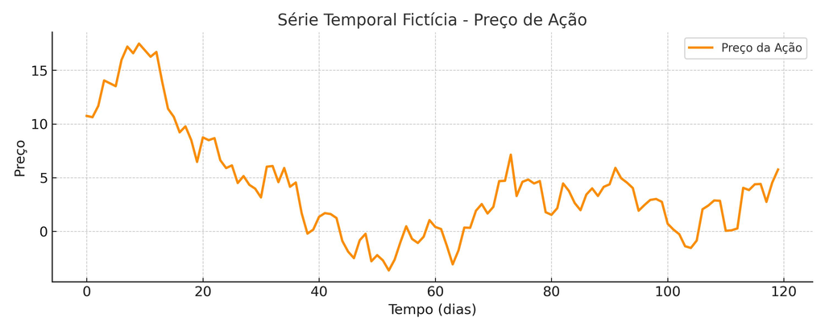

Série Temporal do Preço Diário de uma Ação

## Exemplos de Séries Temporais

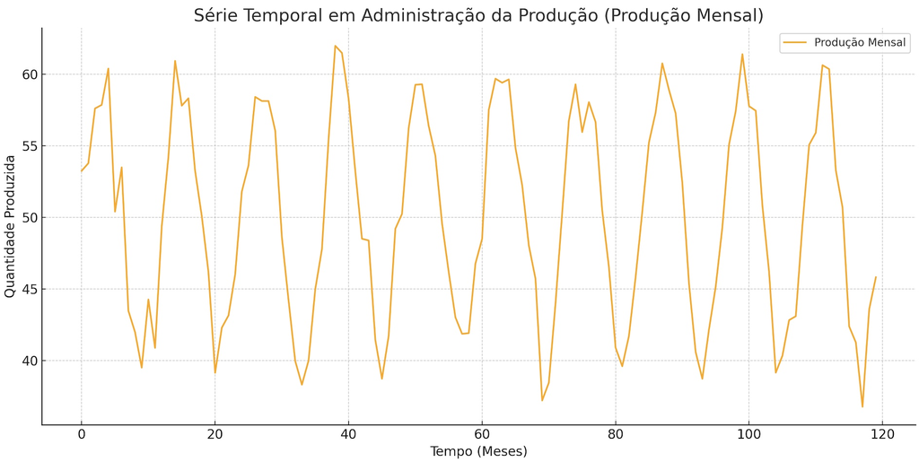

Série Temporal de Produção Mensal

## Exemplos de Séries Temporais

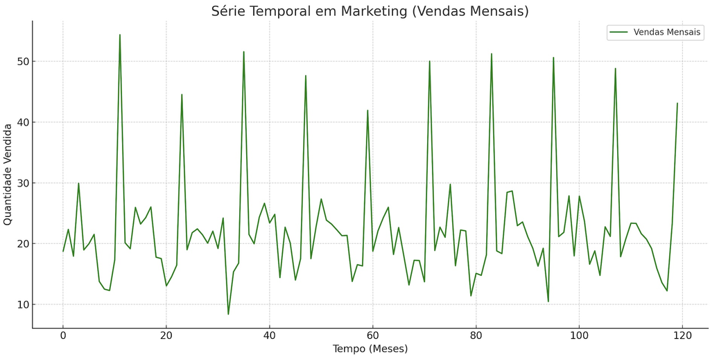

Série Temporal de Venda Mensal

## Tendência

**Descrição**

- A **tendência** refere-se ao **comportamento de longo prazo** de uma série temporal, refletindo a **direção geral dos dados ao longo do tempo**.
- Pode ser **crescente**, **decrescente** ou **estocástica (irregular)**.
- A tendência representa **mudanças persistentes no nível** da série, geralmente associadas a fatores estruturais, como crescimento econômico, avanços tecnológicos ou mudanças demográficas.
- **Exemplo**: Em uma série temporal de vendas de uma empresa ao longo de vários anos, uma tendência crescente pode indicar um aumento sustentado nas vendas.

## Tipos de Tendência

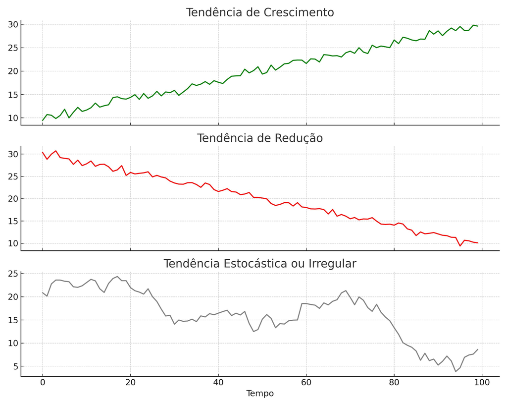

## Sazonalidade

**Definição**

- A **sazonalidade**, ou **padrão sazonal**, refere-se a **flutuações que se repetem em intervalos regulares de tempo**, geralmente dentro de um ano (como variações mensais ou trimestrais).
- Esses padrões decorrem de **fatores sazonais**, como estações do ano, feriados ou eventos recorrentes que influenciam o comportamento da variável ao longo do tempo.
- A sazonalidade pode ser **regular**, quando as flutuações ocorrem de forma constante e previsível.
- Ou **irregular**, quando as flutuações são recorrentes, mas ocorrem com variações na periodicidade, intensidade ou forma.
- **Exemplo**: Aumento nas vendas de sorvetes durante o verão ou pico na venda de brinquedos no Natal.

## Tipos de Sazonalidade

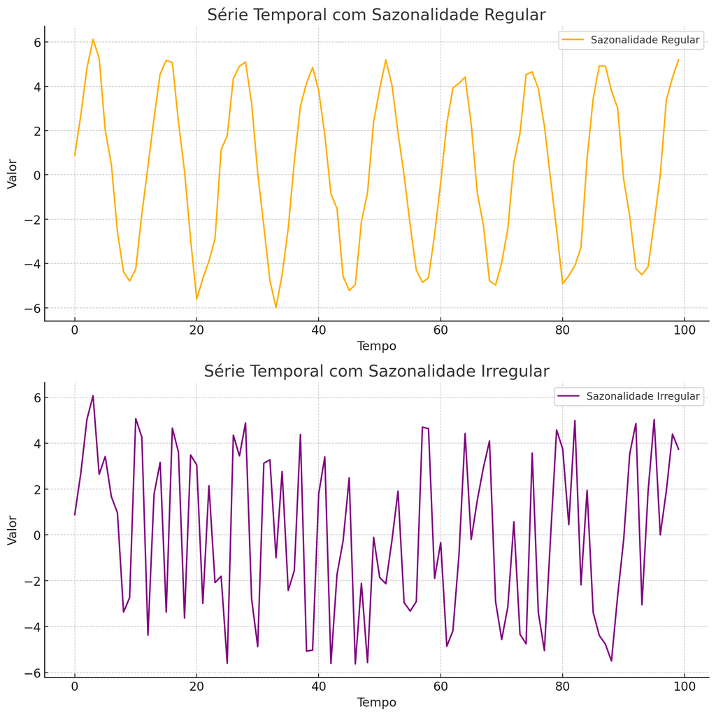

## Séries com Tendência e Sazonalidade

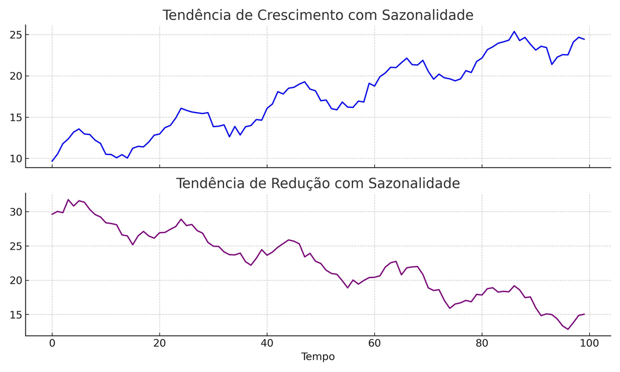

## Ciclos

**Definição**

- Os **ciclos** representam **flutuações de longo prazo em torno da tendência**, que **não se devem à sazonalidade** e ocorrem em **períodos não fixos**, geralmente superiores a um ano.
- São influenciados por **fatores econômicos**, como **recessões** e **expansões**, refletindo fases de crescimento e declínio na economia ou em outros sistemas.
- **Ciclo regular**: as flutuações ocorrem em intervalos constantes e previsíveis, formando um padrão bem definido.
- **Ciclo irregular**: as flutuações, embora recorrentes, ocorrem em intervalos variáveis, com períodos e amplitudes irregulares.

## Tipos de Ciclos

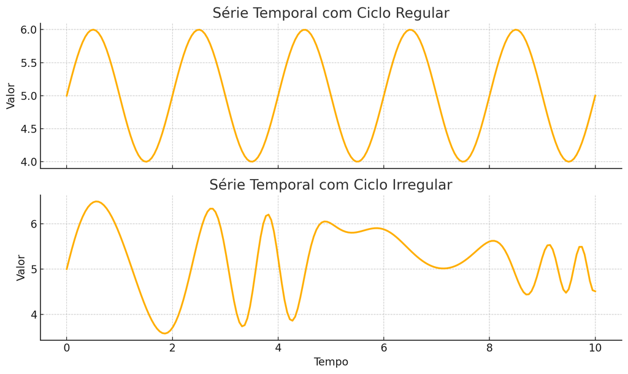

## Exemplo 1 - Análise de Gráfico de Série Temporal

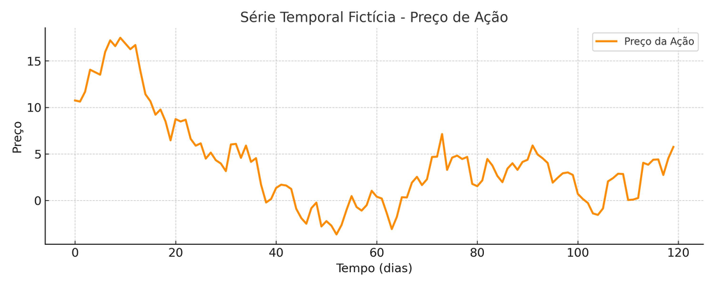

Série Temporal do Preço Diário de uma Ação

**Preço de Ação (Finanças)**

- A série apresenta uma **tendência estocástica (irregular)**, marcada por mudanças abruptas entre fases de alta e de queda nos preços — um comportamento típico da intensa flutuação observada nos mercados acionários.
- Devido à alta volatilidade, que reflete a variabilidade intrínseca desses mercados, torna-se difícil identificar uma tendência geral clara ao longo do tempo.

## Exemplo 2 - Análise de Gráfico de Série Temporal

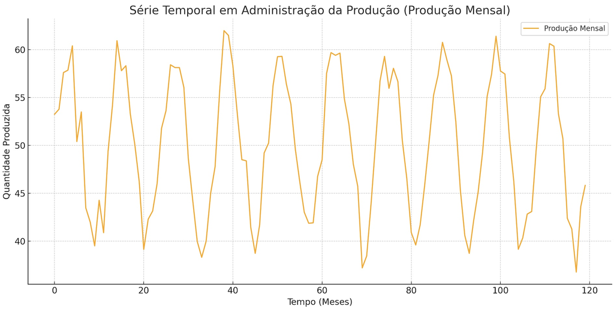

Série Temporal de Produção Mensal

**Produção Mensal (Administração da Produção)**

- A série apresenta uma **sazonalidade** regular evidente, refletindo o padrão de produção mensal de uma fábrica.
- Essa sazonalidade pode ser explicada por variações previsíveis na demanda ao longo do ano, como períodos de maior ou menor consumo do produto.

## Exemplo 3 - Análise de Gráfico de Série Temporal

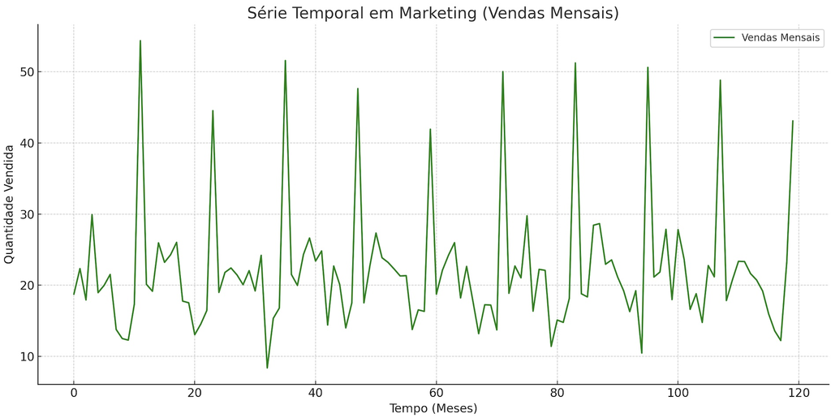

Série Temporal de Venda Mensal

**Vendas Mensais (Marketing)**

- É possível identificar uma **sazonalidade** nas vendas, com picos significativos em determinados meses — como dezembro.
- Esse padrão pode estar relacionado a datas comemorativas, como o Natal e outras, ou a ações promocionais realizadas nesse período.

## Exercício 1

**Enunciado**

A Fig. 1 a seguir mostra o comportamento das vendas mensais de uma empresa ao longo de cinco anos.

**Com base no gráfico, descreva os principais padrões observados na série temporal.**

Você pode considerar aspectos como tendência, sazonalidade e outros da série temporal exibida.

## Exercício 1

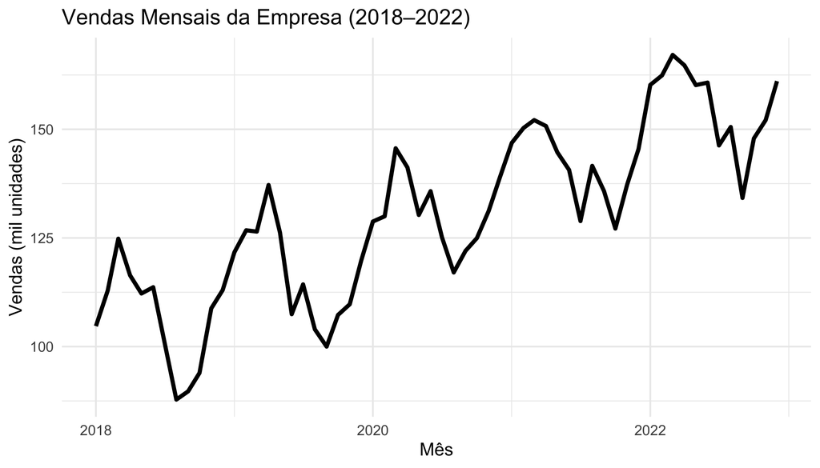

Figura 1: Vendas mensais de uma empresa ao longo de cinco anos.

## Exercício 1 - Resposta

**Resposta de Referência**

- **Tendência:**

Sim, há uma **tendência crescente** clara na série. Ao longo dos cinco anos, observa-se um aumento contínuo no nível geral das vendas. Isso pode indicar crescimento sustentado da empresa, aumento da demanda ou expansão de mercado.

- **Sazonalidade:**

Sim, há **sazonalidade regular**. Notam-se **picos e vales** que se repetem regularmente, sugerindo um padrão sazonal típico, possivelmente influenciado por eventos como sazonalidade climática, campanhas promocionais ou datas comemorativas.

- **Variabilidade:**

A variabilidade é **moderada**, com flutuações relativamente pequenas em torno da tendência e da sazonalidade. Essa **volatilidade limitada** facilita a modelagem e a previsão da série, já que os padrões principais (tendência e sazonalidade) são bem definidos.

## Exercício 2 - ENADE/2022

**Enunciado**

Os executivos da área de gestão de processos e serviços de uma multinacional de telefonia móvel estão analisando o aumento das consultas ao Serviço de Atendimento ao Cliente (SAC) em determinada região do Brasil.

Durante três semanas consecutivas, os profissionais do Departamento de Pesquisa e Desenvolvimento da empresa coletaram dados do SAC relativos a dias úteis das três semanas estudadas, conforme mostra o gráfico a seguir.

## Exercício 2 - ENADE/2022

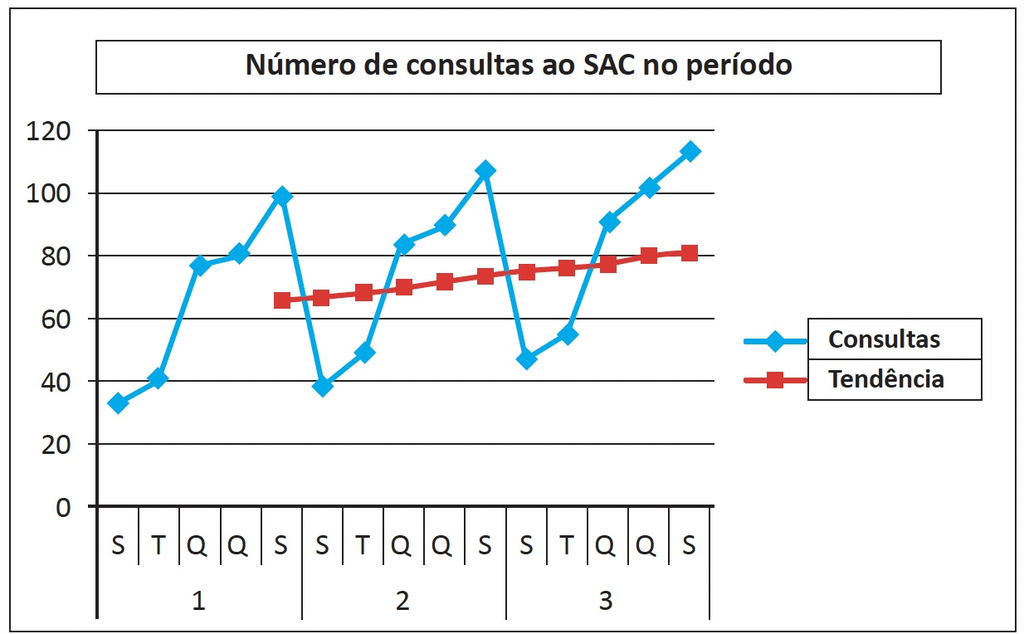

## Exercício 2 - ENADE/2022

**Perguntas**

A gestão da empresa, após analisar o resultado da pesquisa, observou que havia necessidade de expansão do serviço, mesmo considerando o risco associado à implantação desse projeto de expansão, dadas as mudanças no cenário macroeconômico.

Considerando que a amostra represente o universo do fenômeno em questão, avalie as afirmações a seguir.

I. O número de consultas estimado pela equação de regressão linear simples tem aumentado ao longo do tempo.

2. O histórico de dados (n. de consultas ao SAC) apresenta, aparentemente, sazonalidade e distribuição regular.
3. A regressão é o melhor método para prever dados sazonais como, por exemplo, o número de consultas ao SAC na segunda-feira da semana 4.

É correto o que se afirma em

- **A**: I, apenas.
- **B**: III, apenas.
- **C**: I e II, apenas.
- **D**: II e III, apenas.
- **E**: I, II e III.